# HW 5

SDS322E

2021-10-01

## Vaishnavi Sathiyamoorthy vs25229

**Please submit as a knitted HTML file on Canvas before the due date.**

*For all questions, include the R commands/functions that you used to find your answer. Answers without supporting code will not receive credit.*

#### Review of how to submit this assignment

> All homework assignments will be completed using R Markdown. These `.Rmd` files consist of >text/syntax (formatted using Markdown) alongside embedded R code. When you have completed the assignment (by adding R code inside codeblocks and supporting text outside of the codeblocks), create your document as follows:
> - Click the arrow next to the “Knit” button (above)
> - Choose “Knit to HTML”
> - Go to Files pane and put checkmark next to the correct HTML file
> - Click on the blue gear icon (“More”) and click Export
> - Download the file and then upload to Canvas

## Question 1

### 1.1 (2 pts)

###### All subsequent code will be done using the tidyverse (with a focus on `dplyr`), so we need to load this package. We also want to look at the `penguins` dataset which is inside the palmerpenguins package, so we can grab this as well

```r
library(tidyverse)
penguins <- palmerpenguins::penguins
```

###### Using the function `filter()`, pick all the rows/observaions in the `penguins` dataset from the year 2007 and store the result as a new object called `penguins_2007`. Compare the number of observations/rows in the original `penguins` dataset with your new `penguins_2007` dataset in words.

```r
penguins_2007 <- penguins %>%
    filter(year == 2007)
nrow(penguins)
```

```
## [1] 344
```

```r
nrow(penguins_2007)
```

```
## [1] 110
```

*The number of rows in the original rows dataset was 344 and the numvber of rows in the new penguins_2007 dataset is 110.*

### 1.2 (1 pt)

###### Return all the rows in the `penguins_2007` dataset where `bill_length_mm` is between 45 and 55, (doesn’t matter if inclusive of 45 and 55 or not, since no observations have those exact values).

```r
penguins_2007 %>%
    filter(bill_length_mm > 45 & bill_length_mm < 55)
```

```
## # A tibble: 51 × 8
##    species   island   bill_length_mm bill_depth_mm flipper_length_mm body_mass_g
##    <fct>     <fct>             <dbl>         <dbl>             <int>       <int>
##  1 Adelie    Torgers…           46            21.5               194        4200
##  2 Gentoo    Biscoe             46.1          13.2               211        4500
##  3 Gentoo    Biscoe             50            16.3               230        5700
##  4 Gentoo    Biscoe             48.7          14.1               210        4450
##  5 Gentoo    Biscoe             50            15.2               218        5700
##  6 Gentoo    Biscoe             47.6          14.5               215        5400
##  7 Gentoo    Biscoe             46.5          13.5               210        4550
##  8 Gentoo    Biscoe             45.4          14.6               211        4800
##  9 Gentoo    Biscoe             46.7          15.3               219        5200
## 10 Gentoo    Biscoe             46.8          15.4               215        5150
## 11 Gentoo    Biscoe             49            16.1               216        5550
## 12 Gentoo    Biscoe             45.5          13.7               214        4650
```

[output cut: 40 more lines]

### 1.3 (1 pt)

###### Are there any cases in the `penguins_2007` dataset for which the ratio of `bill_length_mm` to `bill_depth_mm` exceeds 3.5? For now, use only `filter()` to find out. If so, for which species of penguins is this true?

```r
penguins_2007 %>%
    filter((bill_length_mm/bill_depth_mm) > 3.5)
```

```
## # A tibble: 2 × 8
##   species island bill_length_mm bill_depth_mm flipper_length_mm body_mass_g
##   <fct>   <fct>           <dbl>         <dbl>             <int>       <int>
## 1 Gentoo  Biscoe           50.2          14.3               218        5700
## 2 Gentoo  Biscoe           59.6          17                 230        6050
## # ℹ 2 more variables: sex <fct>, year <int>
```

*The species that has a bill length to depth ratio greater than 3.5 is Gentoo.*

### 1.4 (1 pt)

###### Take your `penguins_2007` dataset and using `select()`, drop/delete the column `year`, since it isn’t necessary. Overwrite the `penguins_2007` dataset so it no longer contains that column.

```r
penguins_2007 <- penguins_2007 %>%
    select(-year)
```

## Question 2

### 2.1 (1 pt)

###### Using the function `mutate()`, take `penguins_2007` and create a new data column that contains the ratio of `bill_length_mm` to `bill_depth_mm` (call it `bill_ratio`). Overwrite `penguins_2007` so it contains this new column

```r
penguins_2007 <- penguins_2007 %>%
    mutate(bill_ratio = bill_length_mm/bill_depth_mm)
```

### 2.2 (2 pts)

###### Take the `penguins_2007` data and, using `group_by` along with either `arrange` and `slice` or `slice_min`, for *each species* find the three penguins with the shortest bill length. Of those 9 penguins, how many have the value female for the sex variable?

```r
penguins_2007 %>%
    group_by(species) %>%
    arrange(bill_length_mm) %>%
    slice(1:3) %>%
    ungroup() %>%
    summarize(sum(sex == "female", na.rm = T))
```

```
## # A tibble: 1 × 1
##   `sum(sex == "female", na.rm = T)`
##                               <int>
## 1                                 7
```

*7 of the penguins with short beak lengths are female.*

## Question 3

### 3.1 (2 pts)

Using `penguins_2007`, calculate the mean and standard deviation of `bill_ratio` each species using `group_by` and `summarize`. Drop NAs from `bill_ratio` for these computations (e.g., using the argument na.rm=T) so you have values for each species. Which species has the greatest average `bill_ratio`?

```r
penguins_2007 %>%
    group_by(species) %>%
    summarise(mean(bill_ratio, na.rm = T), sd(bill_ratio,
        na.rm = T))
```

```
## # A tibble: 3 × 3
##   species   `mean(bill_ratio, na.rm = T)` `sd(bill_ratio, na.rm = T)`
##   <fct>                             <dbl>                       <dbl>
## 1 Adelie                             2.07                       0.152
## 2 Chinstrap                          2.64                       0.169
## 3 Gentoo                             3.20                       0.157
```

*Gentoos have the greatest average bill ratio.*

### 3.2 (1 pts)

With `penguins_2007`, using either `summarize(n())` or using `count`, report the number of observations for each species-island combination (note that you’ll need to group by both variables!). Which species appears on all three islands?

```r
penguins_2007 %>%
    group_by(species, island) %>%
    summarize(n()) %>%
    filter(n() == 3)
```

```
## # A tibble: 3 × 3
## # Groups:   species [1]
##   species island    `n()`
##   <fct>   <fct>     <int>
## 1 Adelie  Biscoe       10
## 2 Adelie  Dream        20
## 3 Adelie  Torgersen    20
```

*Adelie appears in all three islands.*

## Question 4

### 4.1 (2 pts)

Take the `penguins_2007` data set you have created and using `ggplot` create a single plot showing the distribution of `body_mass_g` for male and female penguins separately, faceted by species (use facet_grid to give each species its own row). Which species has the most NAs for `sex`? Which species shows the least sexual dimorphism (i.e., which shows the greatest overlap of male/female size distributions)?

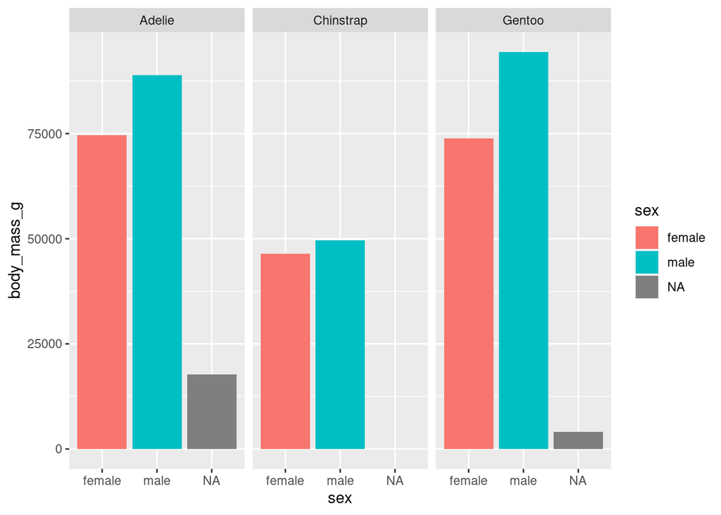

```r
penguins_2007 %>%
    group_by(species) %>%
    ggplot(aes(sex, body_mass_g, fill = sex)) + geom_bar(stat = "identity") +
    facet_grid(~species)
```

*Adelie has the most number of NAs for sex. Chinstrap has the least sexual dimorphism.*

### 4.2 (2 pts)

###### Now, take `penguins_2007` and, using `ggplot`, create a scatterplot of `flipper_length_mm` (x-axis) against the `bill_ratio` variable. Does it look like there is a relationship between length-to-depth ratio and the lengths? To see more clearly, add `geom_smooth(method="lm")` to the plot.

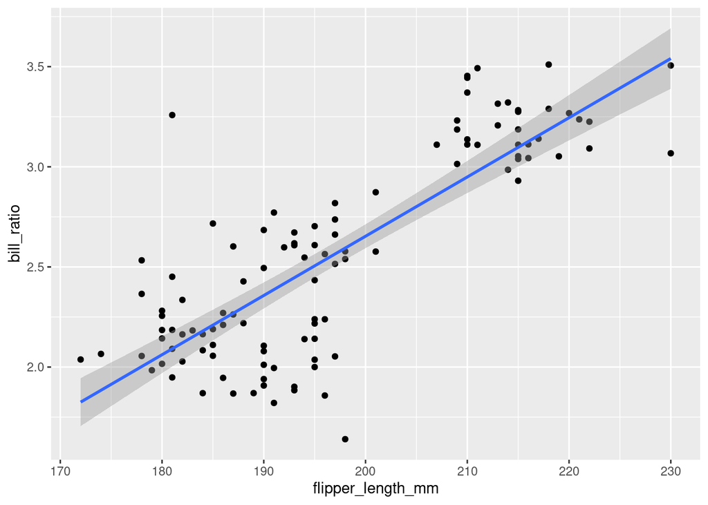

```r
penguins_2007 %>%
    ggplot(aes(flipper_length_mm, bill_ratio)) + geom_point(stat = "identity") +
    geom_smooth(method = "lm")
```

*There is a linear relationship between the length to depth ratio and the flipper lengths.*

### 4.3 (2 pts)

###### Does your answer change when you consider each species individually instead of all together? To see more clearly, duplicate the plot from before but additionally, in the main `ggplot()` function, map `species` to color so each species gets its own color and regression trendline.

###### Compare this plot with the previous one (in 4.2) and discuss whether the relationship between flipper length and bill length-to-depth ratio changes when you look at it overall versus within each species.

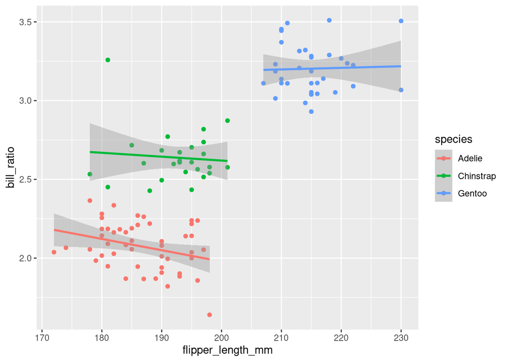

```r
penguins_2007 %>%
    ggplot(aes(flipper_length_mm, bill_ratio, color = species)) +
    geom_point(stat = "identity") + geom_smooth(method = "lm")
```

*There appears to be little to no relationship between the bill ratio and flipper length for Chinstrap and Gentoo. However, there is a slight negative correlation between the two variables for Adelie.*

### 4.4 (3 pts)

###### Finally, let’s make a plot using the original `penguins` dataset (not just the 2007 data). Forewarning: This will be very busy plot!

###### Map `body_mass_g` to the x-axis, `flipper_length_mm` to the y-axis, `species` to color, and `island` to shape and make a scatterplot. Using facet_wrap, facet the plots by `year`. Find a way to clean up the x-axis labels using scale_x_continuous (either include fewer breaks, e.g., with n.breaks=3, or rotate the ones that are there).

###### Does there appear to be a relationship between body mass and flipper length overall? Is there a relationship within each species?

###### What happens to the distribution of flipper lengths for species over time (do you see more or less species overlap for this variable in 2007 relative to 2009)?

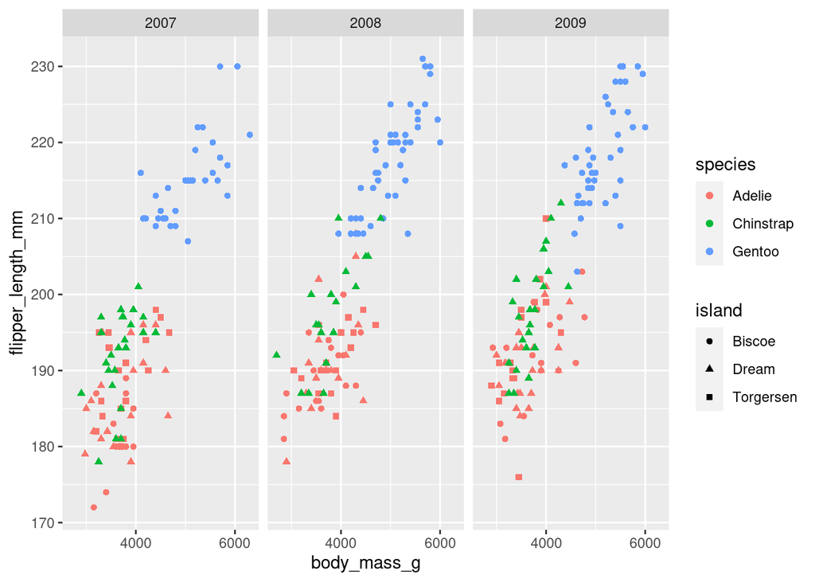

```r
penguins %>%
    ggplot(aes(body_mass_g, flipper_length_mm, color = species,
        shape = island)) + geom_point() + facet_wrap(~year) +
    scale_x_continuous(n.breaks = 3)
```

*There appears to be an overall positive linear relationship between body mass and flipper length. There also appears to be a general positive linear relationship between body mass and flipper length. Over time, there appears to be more overlap between the flipper length of species.*

```
## [1] "2024-10-28 09:11:07 CDT"
```

[output not shown]